# anirudk_newtutorial

Anirud Kashyap

#### Part 1: Data Collection

The dataset using during this tutorial was obtained through this [source](https://github.com/owid/covid-19-data/tree/master). Fortunately, upon examination of the individual datasets within the repository, the data were obtained from the respective country's governmental organization that was collecting the COVID-related data as seen [here](https://github.com/owid/covid-19-data/blob/master/public/data/testing/covid-testing-latest-data-source-details.csv).

All of the individual datasets were stored in the convienent form of a comma-separated value file.

**Imports & Other Misc.**

```python
import pandas as pd
import numpy as np
import warnings
import matplotlib.pyplot as plt
import calendar

warnings.filterwarnings('ignore')
```

```python
vaccinations = pd.read_csv('/Users/anirudkashyap/Downloads/Lecture/New Tutorial/vaccinations.csv')
hospitalizations = pd.read_csv('/Users/anirudkashyap/Downloads/Lecture/New Tutorial/covid-hospitalizations.csv')
deaths = pd.read_csv('/Users/anirudkashyap/Downloads/Lecture/New Tutorial/total_deaths.csv')
combined = pd.read_csv('/Users/anirudkashyap/Downloads/Lecture/New Tutorial/owid-covid-data.csv')
```

#### Part 2: Data Processing

The purpose of this tutorial is to analyze COVID-19 deaths that have taken place on the global scale. The datasets obtained the first part of the data science pipeline contain many useful features and are formatted in a certain way. However, some of these features add no value, and the way the dataset is set up will hinder our ability to analyze the large datasets.

In this part, we will process the data by cleaning it up, reorganizing it, and using an imputation technique mentioned later below so that we are able to carry out the remaining stages of the data science pipeline.

Our end goal is to have one dataframe with all of the respective features combined and no missing data.

Let's go ahead and define some helper functions that will be useful in this step of the pipeline.

This helper function takes in a dataframe (df) and a list of features (columns of the dataframe) that are considered unnecessary and need to be removed.

```python
def remove_unnecessary_features(df, features):
    # Drops the features along axis=1
    return df.drop(features, axis=1)
```

This helper function removes observations in a dataframe that contain a value in a particular feature that will not be used in our data analysis.

```python
def remove_unnecessary_observations(df, feature_name, feature_values):

    # Removes all feature_values from the feature feature_name
    df = df[~df[feature_name].isin(feature_values)]

    # Returns the newly filtered dataframe
    return df
```

This helper function performs a mean imputation technique by filling in the missing np.nan observations with the mean value.

```python
def perform_mean_imp(df, feature_name):
    df[feature_name].fillna(df[feature_name].mean(), inplace=True)
```

This helper function checks to see if the dataframe `df` has any missing values in the feathre `feature_name`.

```python
def missing_values_present(df, feature_name):
    return df[feature_name].isnull().values.any()
```

Now that we have loaded the datasets, let's see what are the features for each dataframe.

```python
vaccinations.columns.to_list()
```

```
['location',
 'iso_code',
 'date',
 'total_vaccinations',
 'people_vaccinated',
 'people_fully_vaccinated',
 'total_boosters',
 'daily_vaccinations_raw',
 'daily_vaccinations',
 'total_vaccinations_per_hundred',
 'people_vaccinated_per_hundred',
 'people_fully_vaccinated_per_hundred',
 'total_boosters_per_hundred',
 'daily_vaccinations_per_million',
 'daily_people_vaccinated',
 'daily_people_vaccinated_per_hundred']
```

```python
hospitalizations.columns.to_list()
```

```
['entity', 'iso_code', 'date', 'indicator', 'value']
```

```python
deaths.columns.to_list()[1:5]
```

```
['World', 'Afghanistan', 'Africa', 'Albania']
```

Since we are interested in the total number of 'x', and not daily in the case of the vaccinations dataset contains, let's go ahead and remove those features and only keep the features that keep track of the 'total'.

```python
features_to_remove = [
    'people_vaccinated',
    'people_fully_vaccinated',
    'daily_vaccinations_raw',
    'daily_vaccinations',
    'daily_vaccinations_per_million',
    'daily_people_vaccinated',
    'daily_people_vaccinated_per_hundred'
]
upd_vaccinations = remove_unnecessary_features(vaccinations, features_to_remove)
upd_vaccinations.columns.to_list()
```

```
['location',
 'iso_code',
 'date',
 'total_vaccinations',
 'total_boosters',
 'total_vaccinations_per_hundred',
 'people_vaccinated_per_hundred',
 'people_fully_vaccinated_per_hundred',
 'total_boosters_per_hundred']
```

Great. Now, as we can see above, the first two datasets contain all of the related data by country and its identifier -- the iso_code. However, the last dataset `deaths`, which contains all of the COVID-19 related deaths, simply has the country name but no iso_code. For the purposes of this tutorial, we will refer to the iso_code in the code, which will allow us to make easier generalizations for each country.

However, before doing that, it's important to note that the deaths dataframe is currently **NOT** tidy in the sense that each country is a feature and each observation is the number of deaths that may have taken place at a given day, as seen below.

```python
deaths.head(5)
```

|  | date | World | Afghanistan | Africa | Albania | Algeria | American Samoa | Andorra | Angola | Anguilla | ... | Uruguay | Uzbekistan | Vanuatu | Vatican | Venezuela | Vietnam | Wallis and Futuna | Yemen | Zambia | Zimbabwe |
| --- | --- | --- | --- | --- | --- | --- | --- | --- | --- | --- | --- | --- | --- | --- | --- | --- | --- | --- | --- | --- | --- |
| 0 | 2020-01-05 | 3.0 | NaN | NaN | NaN | NaN | NaN | NaN | NaN | NaN | ... | NaN | NaN | NaN | NaN | NaN | NaN | NaN | NaN | NaN | NaN |
| 1 | 2020-01-06 | 3.0 | NaN | NaN | NaN | NaN | NaN | NaN | NaN | NaN | ... | NaN | NaN | NaN | NaN | NaN | NaN | NaN | NaN | NaN | NaN |
| 2 | 2020-01-07 | 3.0 | NaN | NaN | NaN | NaN | NaN | NaN | NaN | NaN | ... | NaN | NaN | NaN | NaN | NaN | NaN | NaN | NaN | NaN | NaN |
| 3 | 2020-01-08 | 3.0 | NaN | NaN | NaN | NaN | NaN | NaN | NaN | NaN | ... | NaN | NaN | NaN | NaN | NaN | NaN | NaN | NaN | NaN | NaN |
| 4 | 2020-01-09 | 3.0 | NaN | NaN | NaN | NaN | NaN | NaN | NaN | NaN | ... | NaN | NaN | NaN | NaN | NaN | NaN | NaN | NaN | NaN | NaN |

5 rows × 248 columns

Let's go ahead and "melt" this dataset to make it tidy. Before we melt it, let's go ahead and drop the 'World' column as its data will not be used in this tutorial.

```python
# Removes the 'World' column on the deaths dataframe by calling
# the helper function
deaths = remove_unnecessary_features(deaths, 'World')

# Melts the death dataset, returning a tidy form.
upd_deaths = pd.melt(deaths, id_vars='date', var_name='country', value_name='value')
upd_deaths.head(10)
```

|  | date | country | value |
| --- | --- | --- | --- |
| 0 | 2020-01-05 | Afghanistan | NaN |
| 1 | 2020-01-06 | Afghanistan | NaN |
| 2 | 2020-01-07 | Afghanistan | NaN |
| 3 | 2020-01-08 | Afghanistan | NaN |
| 4 | 2020-01-09 | Afghanistan | NaN |
| 5 | 2020-01-10 | Afghanistan | NaN |
| 6 | 2020-01-11 | Afghanistan | NaN |
| 7 | 2020-01-12 | Afghanistan | NaN |
| 8 | 2020-01-13 | Afghanistan | NaN |
| 9 | 2020-01-14 | Afghanistan | NaN |

Great, now all of our dataframes look relatively the same.

We are interested in the total amount in a feature for a given country. So now let's go ahead and sum up all of the features so that now each country will have its own row and the respective value for the relevant features.

```python
vaccinations.head()
```

|  | location | iso_code | date | total_vaccinations | people_vaccinated | people_fully_vaccinated | total_boosters | daily_vaccinations_raw | daily_vaccinations | total_vaccinations_per_hundred | people_vaccinated_per_hundred | people_fully_vaccinated_per_hundred | total_boosters_per_hundred | daily_vaccinations_per_million | daily_people_vaccinated | daily_people_vaccinated_per_hundred |
| --- | --- | --- | --- | --- | --- | --- | --- | --- | --- | --- | --- | --- | --- | --- | --- | --- |
| 0 | Afghanistan | AFG | 2021-02-22 | 0.0 | 0.0 | NaN | NaN | NaN | NaN | 0.0 | 0.0 | NaN | NaN | NaN | NaN | NaN |
| 1 | Afghanistan | AFG | 2021-02-23 | NaN | NaN | NaN | NaN | NaN | 1367.0 | NaN | NaN | NaN | NaN | 33.0 | 1367.0 | 0.003 |
| 2 | Afghanistan | AFG | 2021-02-24 | NaN | NaN | NaN | NaN | NaN | 1367.0 | NaN | NaN | NaN | NaN | 33.0 | 1367.0 | 0.003 |
| 3 | Afghanistan | AFG | 2021-02-25 | NaN | NaN | NaN | NaN | NaN | 1367.0 | NaN | NaN | NaN | NaN | 33.0 | 1367.0 | 0.003 |
| 4 | Afghanistan | AFG | 2021-02-26 | NaN | NaN | NaN | NaN | NaN | 1367.0 | NaN | NaN | NaN | NaN | 33.0 | 1367.0 | 0.003 |

```python
# Removes the date feature to avoid issues with grouping. However, this
# vaccination dataframe (inc. the date col.) is used in the later part
# of this tutorial.
vaccinations_no_date = remove_unnecessary_features(upd_vaccinations, 'date')
vaccinations_clean = vaccinations_no_date.groupby(['location', 'iso_code']).sum().reset_index()

# Removes the date feature to avoid issues with grouping. However, this
# vaccination dataframe (inc. the date col.) is used in the later part
# of this tutorial.
hospitalizations_no_date = remove_unnecessary_features(hospitalizations, 'date')
hospitalizations_clean = hospitalizations_no_date.groupby(['entity', 'iso_code', 'indicator']).sum().reset_index()
```

**Final Result:**

```python
vaccinations_clean.head(5)
```

|  | location | iso_code | total_vaccinations | total_boosters | total_vaccinations_per_hundred | people_vaccinated_per_hundred | people_fully_vaccinated_per_hundred | total_boosters_per_hundred |
| --- | --- | --- | --- | --- | --- | --- | --- | --- |
| 0 | Afghanistan | AFG | 1.659147e+09 | 9.537989e+07 | 4034.03 | 3497.69 | 3267.78 | 231.94 |
| 1 | Africa | OWID_AFR | 4.915181e+11 | 4.002014e+10 | 34450.57 | 22053.53 | 17463.60 | 2804.86 |
| 2 | Albania | ALB | 3.953643e+08 | 1.828942e+07 | 13910.00 | 6860.83 | 5856.79 | 643.54 |
| 3 | Algeria | DZA | 2.983973e+08 | 3.905993e+06 | 664.55 | 355.30 | 263.07 | 8.68 |
| 4 | Andorra | AND | 5.846260e+06 | 1.014711e+06 | 7322.18 | 3167.77 | 2620.12 | 1270.86 |

```python
hospitalizations_clean.head(5)
```

|  | entity | iso_code | indicator | value |
| --- | --- | --- | --- | --- |
| 0 | Algeria | DZA | Daily ICU occupancy | 16593.000 |
| 1 | Algeria | DZA | Daily ICU occupancy per million | 369.523 |
| 2 | Argentina | ARG | Daily ICU occupancy | 1898676.000 |
| 3 | Argentina | ARG | Daily ICU occupancy per million | 41719.682 |
| 4 | Australia | AUS | Daily ICU occupancy | 97483.000 |

Before we do the same thing to the `upd_deaths` dataframe, there are many missing values that we need to handle before summing it up. However, given the nature of this dataset, we cannot simply impute a value for the missing observations, as it appears tests were not being done at that time (before COVID-19 became a global pandemic).

And so, as a result, those observations will be dropped.

```python
upd_deaths = remove_unnecessary_observations(upd_deaths, 'value', [np.nan]).reset_index()
upd_deaths_no_date = remove_unnecessary_features(upd_deaths, ['date', 'index'])
upd_deaths_clean = upd_deaths_no_date.groupby('country').sum().reset_index()
```

**Final Result:**

```python
upd_deaths_clean.head()
```

|  | country | value |
| --- | --- | --- |
| 0 | Afghanistan | 8530506.0 |
| 1 | Africa | 276122277.0 |
| 2 | Albania | 3891188.0 |
| 3 | Algeria | 7590429.0 |
| 4 | American Samoa | 24163.0 |

Let's go ahead and retrieve the reproduction rate data from the `combined` dataframe and perform similar techniques to properly clean up the dataset.

```python
upd_combined = combined[['iso_code', 'location', 'date', 'reproduction_rate']]
upd_combined = remove_unnecessary_observations(upd_combined, 'reproduction_rate', [np.nan]).reset_index()
upd_combined = remove_unnecessary_features(upd_combined, ['date', 'index'])
upd_combined.head()
```

|  | iso_code | location | reproduction_rate |
| --- | --- | --- | --- |
| 0 | AFG | Afghanistan | 1.51 |
| 1 | AFG | Afghanistan | 1.51 |
| 2 | AFG | Afghanistan | 1.52 |
| 3 | AFG | Afghanistan | 1.51 |
| 4 | AFG | Afghanistan | 1.51 |

Given that the original `combined` dataframe contained the reproduction rate for each country by the date, we will take the mean reproduction rate for each country, which will be the value for the reproduction_rate feature in the final, master dataframe.

```python
reproduction_clean = upd_combined.groupby(['iso_code', 'location'])['reproduction_rate'].mean().reset_index()

reproduction_clean.head()
```

|  | iso_code | location | reproduction_rate |
| --- | --- | --- | --- |
| 0 | AFG | Afghanistan | 1.048525 |
| 1 | AGO | Angola | 0.770684 |
| 2 | ALB | Albania | 1.028571 |
| 3 | AND | Andorra | 0.872687 |
| 4 | ARE | United Arab Emirates | 1.020471 |

Before merging all four dataframes, let's ensure that there are no missing values.

```python
print('Missing Values in Vaccinations: ', vaccinations_clean.isna().any().any())
print('Missing Values in Hospitalizations: ', hospitalizations_clean.isna().any().any())
print('Missing Values in Vaccinations: ', upd_deaths_clean.isna().any().any())
print('Missing Values in Vaccinations: ', reproduction_clean.isna().any().any())
```

```
Missing Values in Vaccinations:  False
Missing Values in Hospitalizations:  False
Missing Values in Vaccinations:  False
Missing Values in Vaccinations:  False
```

Now that all of the datasets are cleaned up, let's go ahead and merge them all together (using an inner join) into one master dataframe that will be used for our data anlysis in the later stages of the data science pipeline.

```python
# Merges both dataframes through inner join
master_df_one = pd.merge(vaccinations_clean, hospitalizations_clean, left_on='location', right_on='entity', how='inner')
master_df_one.head()
```

|  | location | iso_code_x | total_vaccinations | total_boosters | total_vaccinations_per_hundred | people_vaccinated_per_hundred | people_fully_vaccinated_per_hundred | total_boosters_per_hundred | entity | iso_code_y | indicator | value |
| --- | --- | --- | --- | --- | --- | --- | --- | --- | --- | --- | --- | --- |
| 0 | Algeria | DZA | 2.983973e+08 | 3.905993e+06 | 664.55 | 355.30 | 263.07 | 8.68 | Algeria | DZA | Daily ICU occupancy | 16593.000 |
| 1 | Algeria | DZA | 2.983973e+08 | 3.905993e+06 | 664.55 | 355.30 | 263.07 | 8.68 | Algeria | DZA | Daily ICU occupancy per million | 369.523 |
| 2 | Argentina | ARG | 9.376212e+10 | 2.363824e+10 | 206023.97 | 83254.30 | 65530.28 | 51940.04 | Argentina | ARG | Daily ICU occupancy | 1898676.000 |
| 3 | Argentina | ARG | 9.376212e+10 | 2.363824e+10 | 206023.97 | 83254.30 | 65530.28 | 51940.04 | Argentina | ARG | Daily ICU occupancy per million | 41719.682 |
| 4 | Australia | AUS | 1.921571e+10 | 3.560549e+09 | 73405.65 | 19324.18 | 21222.67 | 13601.55 | Australia | AUS | Daily ICU occupancy | 97483.000 |

Now let's go ahead and clean up this new master dataframe before merging the `upd_deaths_clean` dataframe.

```python
master_df_one = remove_unnecessary_features(master_df_one, ['entity', 'iso_code_y'])
master_df_one = master_df_one.rename(columns={'iso_code_x':'iso_code', 'value':'hospitalizations'})
```

Let's go ahead and repeat the same for the `upd_deaths_clean` and `reproduction_clean` dataframes.

```python
upd_deaths_clean.head()
```

|  | country | value |
| --- | --- | --- |
| 0 | Afghanistan | 8530506.0 |
| 1 | Africa | 276122277.0 |
| 2 | Albania | 3891188.0 |
| 3 | Algeria | 7590429.0 |
| 4 | American Samoa | 24163.0 |

```python
# Performs an inner join between master_df_one and upd_deaths_clean
master_df = pd.merge(master_df_one, upd_deaths_clean, left_on='location', right_on='country', how='inner')

# Removes the duplicate country column that was created as a result
# of the merge
master_df = remove_unnecessary_features(master_df, ['country'])

# Renames the value column to deaths
master_df = master_df.rename(columns={'value':'deaths'})

# Renames location column to country
reproduction_clean = reproduction_clean.rename(columns={'location':'country'})

# Performs an inner join between master_Df and reproduction_clean
master_df = pd.merge(master_df, reproduction_clean, left_on='location', right_on='country', how='inner')

# Removes the duplicate country and iso_code_y columns that was created as a result
# of the merge
master_df = remove_unnecessary_features(master_df, ['country', 'iso_code_y'])

# Renames the iso_code_x column to iso_code
master_df = master_df.rename(columns={'iso_code_x':'iso_code'})

master_df.head()
```

|  | location | iso_code | total_vaccinations | total_boosters | total_vaccinations_per_hundred | people_vaccinated_per_hundred | people_fully_vaccinated_per_hundred | total_boosters_per_hundred | indicator | hospitalizations | deaths | reproduction_rate |
| --- | --- | --- | --- | --- | --- | --- | --- | --- | --- | --- | --- | --- |
| 0 | Algeria | DZA | 2.983973e+08 | 3.905993e+06 | 664.55 | 355.30 | 263.07 | 8.68 | Daily ICU occupancy | 16593.000 | 7590429.0 | 1.003451 |
| 1 | Algeria | DZA | 2.983973e+08 | 3.905993e+06 | 664.55 | 355.30 | 263.07 | 8.68 | Daily ICU occupancy per million | 369.523 | 7590429.0 | 1.003451 |
| 2 | Argentina | ARG | 9.376212e+10 | 2.363824e+10 | 206023.97 | 83254.30 | 65530.28 | 51940.04 | Daily ICU occupancy | 1898676.000 | 145850302.0 | 0.969853 |
| 3 | Argentina | ARG | 9.376212e+10 | 2.363824e+10 | 206023.97 | 83254.30 | 65530.28 | 51940.04 | Daily ICU occupancy per million | 41719.682 | 145850302.0 | 0.969853 |
| 4 | Australia | AUS | 1.921571e+10 | 3.560549e+09 | 73405.65 | 19324.18 | 21222.67 | 13601.55 | Daily ICU occupancy | 97483.000 | 15034638.0 | 1.095496 |

#### Part 3: Exploratory Analysis & Data Visualization

Now that we have a version of our dataset that has been cleaned, filtered, and processed, we are ready to proceed to the next stage of the data science of exploring and visualizing our dataset.

We are interested in analysing the COVID-19 deaths that depend on various factors such as vaccinations, hospilizations, etc. Let's try to see some trends between the COVID-19 deaths all of our relevant features including but not limited to boosters, vaccinations, hospitalizations, etc. in our dataset.

Let's first see how the COVID-19 deaths have trended over time in all of the countries and make any possible conjectures based on the visualization.

```python
# deaths by month
upd_deaths = remove_unnecessary_features(upd_deaths, 'index')
```

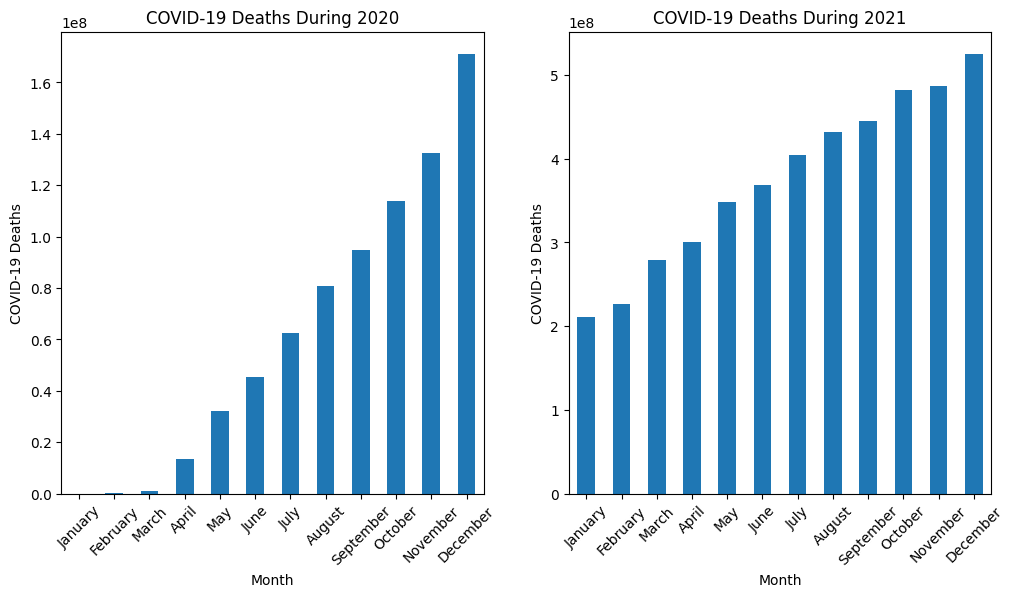

```python
# Makes the graph more readable
months = [calendar.month_name[i] for i in range(1,13)]

# Helper function that graphs the COVID-19 deaths data
# in the dataframe df for a given year
def graph_plot(df, year, title, ylabel):

    df['date'] = pd.to_datetime(df['date'])

    df_filt = df[df['date'].dt.year == year[0]]

    # Computes the sum of COVID-19 deaths for a given month
    data_one = df_filt.groupby(df_filt['date'].dt.month)['value'].sum()

    # Handles case where graph for the January of next year
    # shows up in the plot
    if len(data_one) != 12:
        data_one = data_one.reindex(range(1, 13),fill_value=0)

    # Plots the data for the first year
    plt.figure(figsize=(12,6))
    plt.subplot(1,2,1)
    data_one.plot(kind='bar')

    # Makes the x axis more readable by using the months
    # that was formatted thanks to the calendar library
    plt.xticks(range(12), months, rotation=45)
    plt.xlabel('Month')
    plt.ylabel(ylabel)
    plt.title(title[0])

    ##########################################
    # Code below is a repeat of the code above
    ##########################################
    df['date'] = pd.to_datetime(df['date'])

    df_filt = df[df['date'].dt.year == year[1]]

    data_one = df_filt.groupby(df_filt['date'].dt.month)['value'].sum()

    plt.subplot(1,2,2)
    data_one.plot(kind='bar')

    plt.xticks(range(12), months, rotation=45)
    plt.xlabel('Month')
    plt.ylabel(ylabel)
    plt.title(title[1])

upd_deaths_copy = upd_deaths.copy()
graph_plot(upd_deaths_copy, [2020,2021], ['COVID-19 Deaths During 2020','COVID-19 Deaths During 2021'], 'COVID-19 Deaths')
```

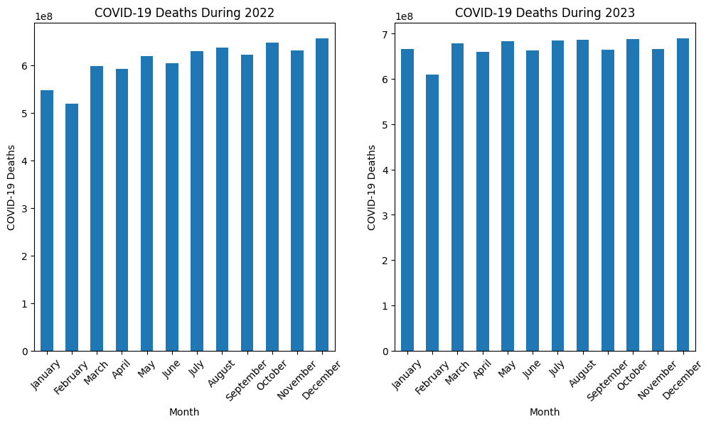

```python
graph_plot(upd_deaths_copy, [2022,2023], ['COVID-19 Deaths During 2022','COVID-19 Deaths During 2023'], 'COVID-19 Deaths')
```

**As we can see in the above plots, COVID-19 was increasing at a significantly high rate during the year 2020 [when the outbreak was characterized as a pandemic by the World Health Organization (WHO)](https://www.nfid.org/infectious-diseases/covid-19/). It continued into 2021, but began to level off and remain steady (with occasional dips) in 2022 and 2023, 2-3 years following the start of the pandemic.**

*It's important to observe we are just noting some of the observations of these plots and NOT making any conjectures.*

Now let's go ahead and see the plot vaccination rate over the same four years to see if there is a similar trend.

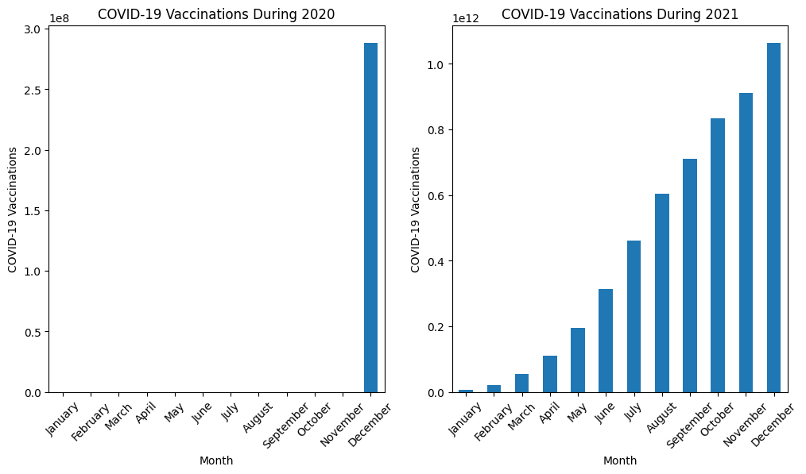

```python
vaccinations_interest = upd_vaccinations[['location', 'iso_code', 'date', 'total_vaccinations']]

vaccinations_interest.rename(columns={'total_vaccinations':'value'},inplace=True)

graph_plot(vaccinations_interest, [2020, 2021], ['COVID-19 Vaccinations During 2020', 'COVID-19 Vaccinations During 2021'],
    'COVID-19 Vaccinations')
```

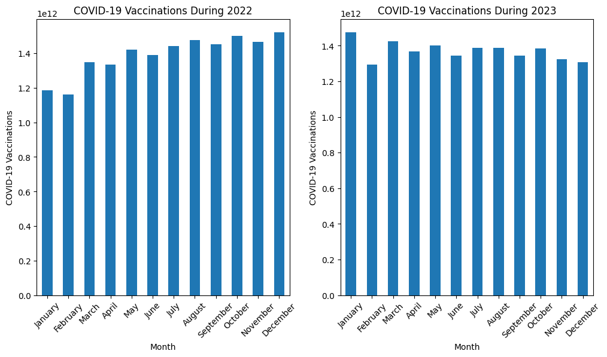

```python
graph_plot(vaccinations_interest, [2022, 2023], ['COVID-19 Vaccinations During 2022', 'COVID-19 Vaccinations During 2023'],
    'COVID-19 Vaccinations')
```

**Similar to the plots of COVID-19 deaths, there was a significant increase in the number of single/double (not booster) shot vaccinations during the end of 2020 and all of 2021. However, it should be noted that there is a lot of missing data in the 2020 dataset, and imputation techniques such as mean imputation, interpolation, etc. wouldn't necessarily help here, as it seems like it simply wasn't being logged by the source during the time.**

**However, during the years of 2022 and 2023, the amount of COVID_19 vaccinations remained stagnant. It should be noted that there were more COVID-19 vaccinations than COVID-19 deaths.**

*It's important to observe we are just noting some of the observations of these plots and NOT making any conjectures.*

Now let's see how the COVID-19 hospitalizations relate to these trends.

```python
hospitalizations['indicator'].unique()
```

```
array(['Daily ICU occupancy', 'Daily ICU occupancy per million',
       'Daily hospital occupancy', 'Daily hospital occupancy per million',
       'Weekly new hospital admissions',
       'Weekly new hospital admissions per million',
       'Weekly new ICU admissions',
       'Weekly new ICU admissions per million'], dtype=object)
```

```python
# Helper function that graphs the hospitalizations rate data
# that's in the dataframe df for the year.
def graph_hospitalizations(df, year, title, color):

    # Filters out the dataframe so that we only have the Daily ICU occupancy rate and observations
    # that were collected during the year
    df_new = df[(df['indicator'] == 'Daily ICU occupancy') & (df['date'].str.startswith(year))]

    df_new['date'] = pd.to_datetime(df_new['date'])

    # Sorts the dataframe by the date for processing
    df_new = df_new.sort_values(by='date')

    # Plots the data
    plt.plot(df_new['date'], df_new['value'], marker='o', color=color)
    plt.xticks(rotation=45)
    plt.xlabel('Month')
    plt.ylabel('Daily ICU Occupancy')
    plt.title(title)
```

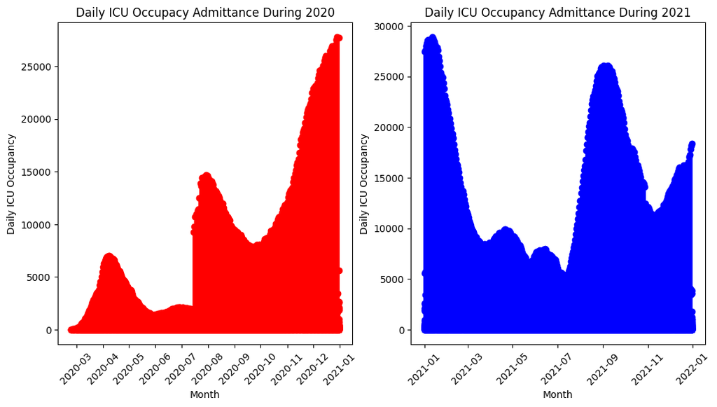

```python
plt.figure(figsize=(12,6))
plt.subplot(1,2,1)
graph_hospitalizations(hospitalizations, '2020', 'Daily ICU Occupacy Admittance During 2020', 'r')
plt.subplot(1,2,2)
graph_hospitalizations(hospitalizations, '2021', 'Daily ICU Occupancy Admittance During 2021', 'b')
```

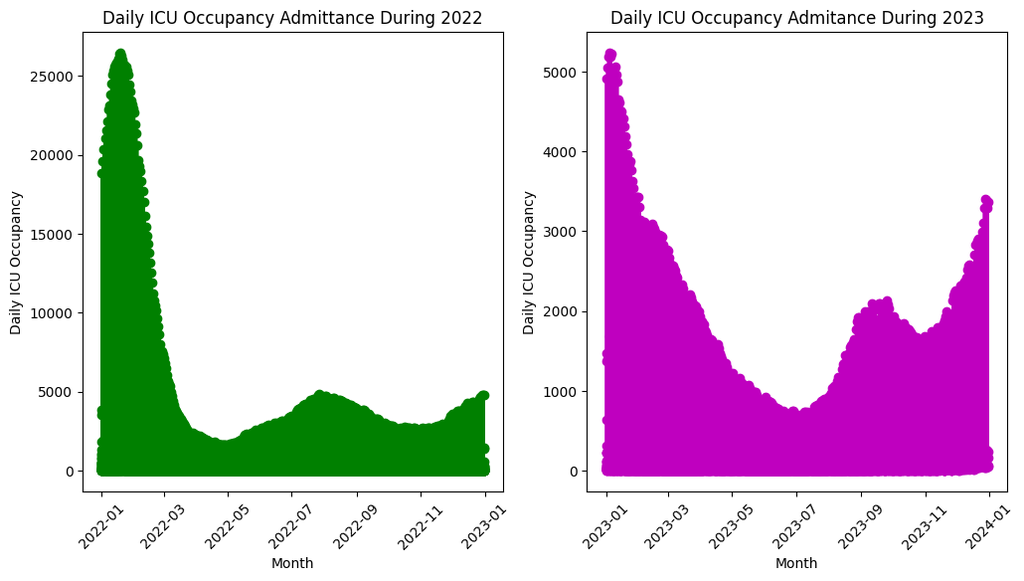

```python
plt.figure(figsize=(12,6))
plt.subplot(1,2,1)
graph_hospitalizations(hospitalizations, '2022', 'Daily ICU Occupancy Admittance During 2022', 'g')
plt.subplot(1,2,2)
graph_hospitalizations(hospitalizations, '2023', 'Daily ICU Occupancy Admitance During 2023', 'm')
```

**Furthermore, we can see that in 2022 and 2023, the number of daily admittance to the ICU had decreased significantly (25000-> ~5000), which was during the period where the amount of COVID-19 vaccinations being administered remained roughly stagnant. It should also be noted that the number of deaths was flucuating as seen earlier in this tutorial.**

*It's important to observe we are just noting some of the observations of these plots and NOT making any conjectures.*

Let's see how the reproduction rate relates to these trends.

```python
# Helper function that graphs the reproduction rate data
# in the dataframe df for the year
def graph_rr(df, year, title, color):

    # Filters out the dataframe so that only the observations
    # collected during year are there
    df = df[df['date'].str.startswith(year)]
    df['date'] = pd.to_datetime(df['date'])

    # Sorts the dataframe by the date for proessing
    df = df.sort_values(by='date')

    # Plots the reproduction rate
    plt.plot(df['date'], df['reproduction_rate'], color=color)
    plt.xlabel('Month')
    plt.ylabel('COVID-19 Reproduction Rate')
    plt.title(title)
```

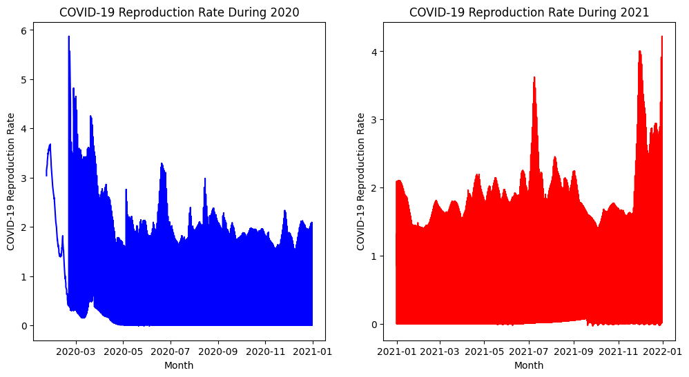

```python
combined_filt = combined[['iso_code', 'location', 'date', 'population', 'reproduction_rate']].dropna(subset=['reproduction_rate'])
plt.figure(figsize=(12,6))
plt.subplot(1,2,1)
graph_rr(combined_filt, '2020', 'COVID-19 Reproduction Rate During 2020', 'b')
plt.subplot(1,2,2)
graph_rr(combined_filt, '2021', 'COVID-19 Reproduction Rate During 2021', 'r')
```

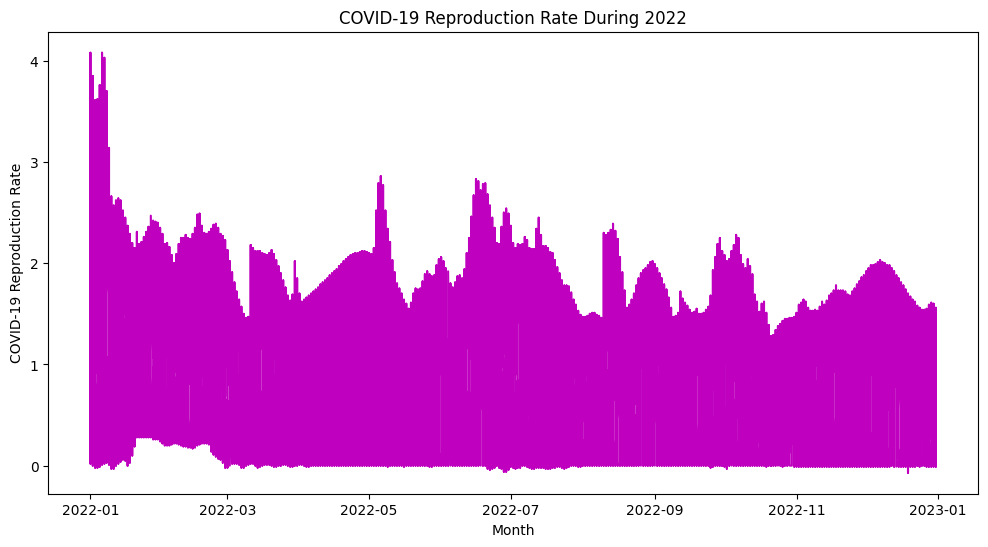

```python
plt.figure(figsize=(12,6))
graph_rr(combined_filt, '2022', 'COVID-19 Reproduction Rate During 2022', 'm')
```

**It's interesting to note that during September of 2021, the reproduction rate of COVID-19 and reached its lowest point for that year. Similarly, looking at the ICU occupancy admittance chart during that time in 2021, the ICU occupancy increased.**

*It's important to observe we are just noting some of the observations of these plots and NOT making any conjectures.*

Now that we have seen some of the trends for the individual features that will make up our model that will be trained later on in this tutorial, let's see how our features (which will be discussed in depth below) vaccinations, hospitilizations, and reproduction rate impact our dependent variable of `deaths`.